# Análisis exploratorio de datos

Silvia Pérez

2025-05-04

## Datos Abalone

La edad del abalone (especie de crustaceo) se determina cortando su caparazón a traves del cono, y contando el numero de anillos a traves del microscopio.

Fuente: https://archive.ics.uci.edu/datasets

```r
library(readr)
```

Ahora cargamos los datos

```r
datos <- read.table("abalone.txt", header = F, sep = ",")

head(datos) #para que muestre las primeras 6 filas
```

|  | V1 | V2 | V3 | V4 | V5 | V6 | V7 | V8 | V9 |
| --- | --- | --- | --- | --- | --- | --- | --- | --- | --- |
| 1 | M | 0.455 | 0.365 | 0.095 | 0.5140 | 0.2245 | 0.1010 | 0.150 | 15 |
| 2 | M | 0.350 | 0.265 | 0.090 | 0.2255 | 0.0995 | 0.0485 | 0.070 | 7 |
| 3 | F | 0.530 | 0.420 | 0.135 | 0.6770 | 0.2565 | 0.1415 | 0.210 | 9 |
| 4 | M | 0.440 | 0.365 | 0.125 | 0.5160 | 0.2155 | 0.1140 | 0.155 | 10 |
| 5 | I | 0.330 | 0.255 | 0.080 | 0.2050 | 0.0895 | 0.0395 | 0.055 | 7 |
| 6 | I | 0.425 | 0.300 | 0.095 | 0.3515 | 0.1410 | 0.0775 | 0.120 | 8 |

Vamos a poner nombre a las variables y luego mostramos el archivo:

```r
colnames(datos)<-c("Genero", "Long","Diam","Altura","Peso","Peso1","Peso2","Peso3","N.anillos")
head(datos)
```

|  | Genero | Long | Diam | Altura | Peso | Peso1 | Peso2 | Peso3 | N.anillos |
| --- | --- | --- | --- | --- | --- | --- | --- | --- | --- |
| 1 | M | 0.455 | 0.365 | 0.095 | 0.5140 | 0.2245 | 0.1010 | 0.150 | 15 |
| 2 | M | 0.350 | 0.265 | 0.090 | 0.2255 | 0.0995 | 0.0485 | 0.070 | 7 |
| 3 | F | 0.530 | 0.420 | 0.135 | 0.6770 | 0.2565 | 0.1415 | 0.210 | 9 |
| 4 | M | 0.440 | 0.365 | 0.125 | 0.5160 | 0.2155 | 0.1140 | 0.155 | 10 |
| 5 | I | 0.330 | 0.255 | 0.080 | 0.2050 | 0.0895 | 0.0395 | 0.055 | 7 |
| 6 | I | 0.425 | 0.300 | 0.095 | 0.3515 | 0.1410 | 0.0775 | 0.120 | 8 |

Veamos el tipo de variables que hay:

```r
str(datos)
```

```
## 'data.frame':    4177 obs. of  9 variables:
##  $ Genero   : chr  "M" "M" "F" "M" ...
##  $ Long     : num  0.455 0.35 0.53 0.44 0.33 0.425 0.53 0.545 0.475 0.55 ...
##  $ Diam     : num  0.365 0.265 0.42 0.365 0.255 0.3 0.415 0.425 0.37 0.44 ...
##  $ Altura   : num  0.095 0.09 0.135 0.125 0.08 0.095 0.15 0.125 0.125 0.15 ...
##  $ Peso     : num  0.514 0.226 0.677 0.516 0.205 ...
##  $ Peso1    : num  0.2245 0.0995 0.2565 0.2155 0.0895 ...
##  $ Peso2    : num  0.101 0.0485 0.1415 0.114 0.0395 ...
##  $ Peso3    : num  0.15 0.07 0.21 0.155 0.055 0.12 0.33 0.26 0.165 0.32 ...
##  $ N.anillos: int  15 7 9 10 7 8 20 16 9 19 ...
```

Necesitamos convertir la variable Genero a factor, porque la tomó como caracter (y eso solo sería como una cadena de texto, pero factor reconoce como niveles!)

```r
datos$Genero<- as.factor(datos$Genero)
summary(datos)
```

```
##  Genero        Long            Diam            Altura            Peso
##  F:1307   Min.   :0.075   Min.   :0.0550   Min.   :0.0000   Min.   :0.0020
##  I:1342   1st Qu.:0.450   1st Qu.:0.3500   1st Qu.:0.1150   1st Qu.:0.4415
##  M:1528   Median :0.545   Median :0.4250   Median :0.1400   Median :0.7995
##           Mean   :0.524   Mean   :0.4079   Mean   :0.1395   Mean   :0.8287
##           3rd Qu.:0.615   3rd Qu.:0.4800   3rd Qu.:0.1650   3rd Qu.:1.1530
##           Max.   :0.815   Max.   :0.6500   Max.   :1.1300   Max.   :2.8255
##      Peso1            Peso2            Peso3          N.anillos
##  Min.   :0.0010   Min.   :0.0005   Min.   :0.0015   Min.   : 1.000
##  1st Qu.:0.1860   1st Qu.:0.0935   1st Qu.:0.1300   1st Qu.: 8.000
##  Median :0.3360   Median :0.1710   Median :0.2340   Median : 9.000
##  Mean   :0.3594   Mean   :0.1806   Mean   :0.2388   Mean   : 9.934
##  3rd Qu.:0.5020   3rd Qu.:0.2530   3rd Qu.:0.3290   3rd Qu.:11.000
##  Max.   :1.4880   Max.   :0.7600   Max.   :1.0050   Max.   :29.000
```

### Visualizando VARIABLES CUALITATIVAS

Veamos cómo pueden representarse dos variables de este tipo.

### Gráficos de BARRAS

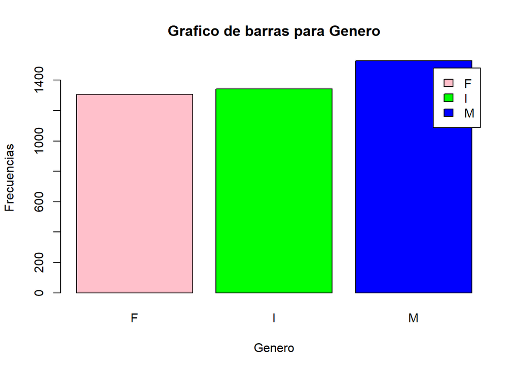

```r
attach(datos)
#uno básico: con Rbase:
frecG<-table(Genero)
barplot(frecG,main="Grafico de barras para Genero",
        xlab="Genero",                   #Tíulo del eje X
        ylab="Frecuencias",                   #Título del eje Y
        col=c("pink","green","blue"),
        legend = rownames(frecG))    #Mostrar las leyendas
```

### Gráficos de TORTAS o SECTORES

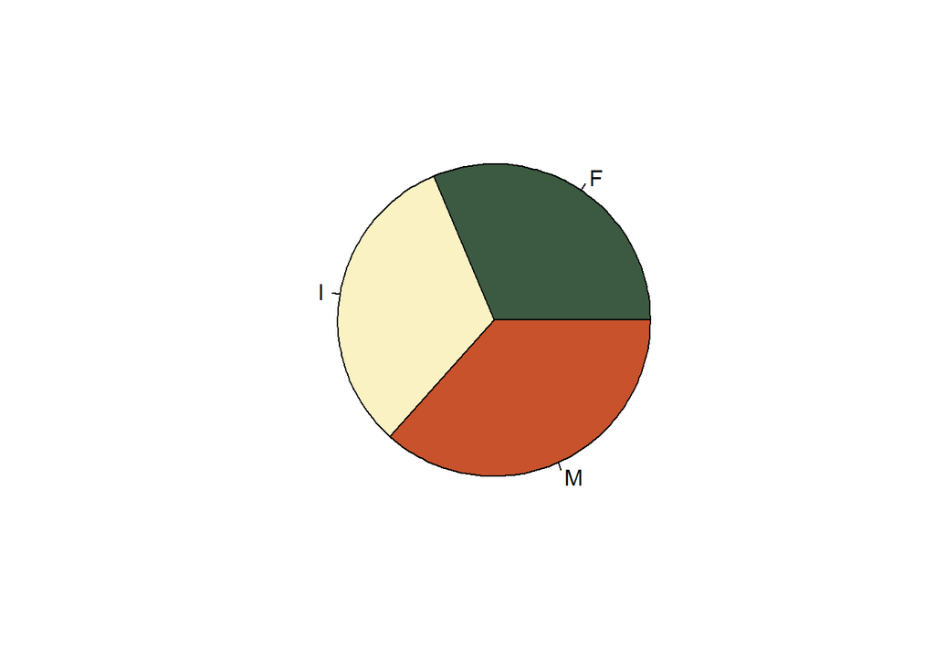

```r
# para la variable Genero:
# Gráfico de sectores
pie(frecG,col = hcl.colors(length(frecG), "Fall"))
```

### Tabla de FRECUENCIAS para una variable cualitativa

```r
# para la variable Genero:
prop.table(frecG) # da las frecuencias relativas
```

```
## Genero
##         F         I         M
## 0.3129040 0.3212832 0.3658128
```

## Visualizando VARIABLES CUANTITATIVAS

### Histograma

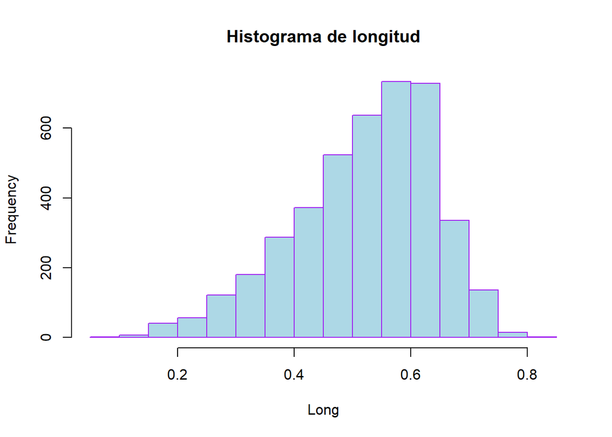

```r
histo<-hist(Long,breaks = 12,main="Histograma de longitud",col = "lightblue", border = "purple")
```

El histograma se basa en la tabla de frecuencias.El anterior (típico), si no se especifica “breaks” usa el criterio de Sturges para construír las clases (# intervalos aproximadamente igual a 1+3,3log²(n)). Podemos ver ‘el detrás de escena’ del histograma con lo siguiente:

```r
histo
```

```
## $breaks
##  [1] 0.05 0.10 0.15 0.20 0.25 0.30 0.35 0.40 0.45 0.50 0.55 0.60 0.65 0.70 0.75
## [16] 0.80 0.85
##
## $counts
##  [1]   1   7  41  57 122 180 287 372 524 637 733 728 336 136  15   1
##
## $density
##  [1] 0.004788125 0.033516878 0.196313143 0.272923151 0.584151305 0.861862581
##  [7] 1.374192004 1.781182667 2.508977735 3.050035911 3.509695954 3.485755327
## [13] 1.608810151 0.651185061 0.071821882 0.004788125
##
## $mids
##  [1] 0.075 0.125 0.175 0.225 0.275 0.325 0.375 0.425 0.475 0.525 0.575 0.625
## [13] 0.675 0.725 0.775 0.825
##
## $xname
## [1] "Long"
##
## $equidist
## [1] TRUE
##
## attr(,"class")
## [1] "histogram"
```

Las frecuencias en cada intervalo pueden verse en “counts”, y “density” corresponde a las frecuencias relativas divididas por la amplitud del intervalo. Esto se hace para obtener el histograma que tenga área total igual a 1.

### Box-plot o diagrama de cajas-bigotes

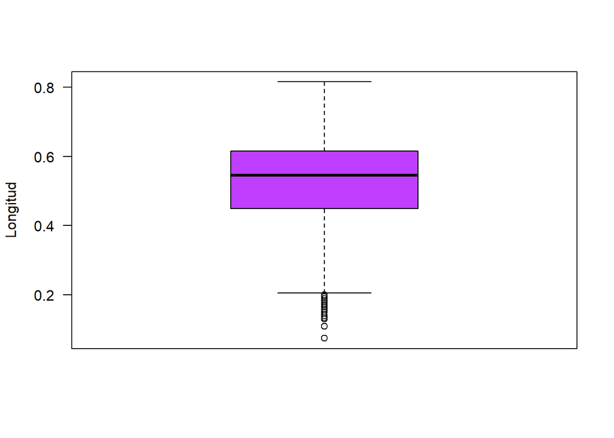

```r
boxplot(Long, las=1, col="darkorchid1", #horizontal=TRUE,
        ylab="Longitud")
```

Hagamos esto para todas las variables numéricas. Antes vamos a seleccionarlas:

```r
library(dplyr)
datos_num <- select_if(datos[,-1], is.numeric) #usa dplyr
summary(datos_num)
```

```
##       Long            Diam            Altura            Peso
##  Min.   :0.075   Min.   :0.0550   Min.   :0.0000   Min.   :0.0020
##  1st Qu.:0.450   1st Qu.:0.3500   1st Qu.:0.1150   1st Qu.:0.4415
##  Median :0.545   Median :0.4250   Median :0.1400   Median :0.7995
##  Mean   :0.524   Mean   :0.4079   Mean   :0.1395   Mean   :0.8287
##  3rd Qu.:0.615   3rd Qu.:0.4800   3rd Qu.:0.1650   3rd Qu.:1.1530
##  Max.   :0.815   Max.   :0.6500   Max.   :1.1300   Max.   :2.8255
##      Peso1            Peso2            Peso3          N.anillos
##  Min.   :0.0010   Min.   :0.0005   Min.   :0.0015   Min.   : 1.000
##  1st Qu.:0.1860   1st Qu.:0.0935   1st Qu.:0.1300   1st Qu.: 8.000
##  Median :0.3360   Median :0.1710   Median :0.2340   Median : 9.000
##  Mean   :0.3594   Mean   :0.1806   Mean   :0.2388   Mean   : 9.934
##  3rd Qu.:0.5020   3rd Qu.:0.2530   3rd Qu.:0.3290   3rd Qu.:11.000
##  Max.   :1.4880   Max.   :0.7600   Max.   :1.0050   Max.   :29.000
```

Entondes podemos ver algunos gráficos juntos:

```r
attach(datos_num)
```

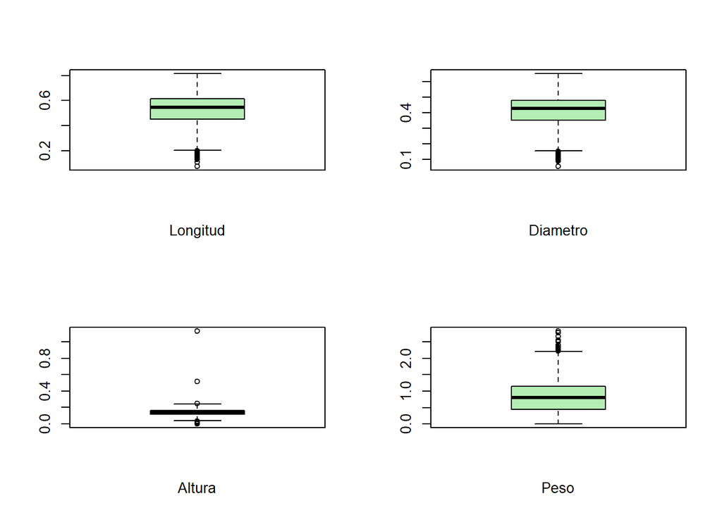

```r
par(mfrow = c(2, 2))
boxplot(Long, col="darkseagreen2",
               xlab="Longitud")
boxplot(Diam,  col="darkseagreen2",
               xlab="Diametro")
boxplot(Altura, col="darkseagreen2",
                xlab="Altura")
boxplot(Peso, col="darkseagreen2",
                xlab="Peso")
```

```r
par(mfrow = c(1,1))
```

## GRAFICOS BIVARIADOS

### Visualizando CATEGORICA VS CATEGORICA

Primero vamos a categorizar la variable N_anillos usando el paquete dplyr:

```r
### -- DISCRETIZAR VARIABLES --

# defino la variable discretizada
datos <- datos %>%
  mutate(anillos_disc  = case_when(.$N.anillos <= 8 ~ "pocos",
                                   .$N.anillos <= 11 ~ "normal",
                                          TRUE ~ "muchos"
  ))
#View(datos)
datos$anillos_disc<- as.factor(datos$anillos_disc) #no hace falta si pusimos attach(datos)
#anillos_disc<- as.factor(anillos_disc)
summary(datos)
```

```
##  Genero        Long            Diam            Altura            Peso
##  F:1307   Min.   :0.075   Min.   :0.0550   Min.   :0.0000   Min.   :0.0020
##  I:1342   1st Qu.:0.450   1st Qu.:0.3500   1st Qu.:0.1150   1st Qu.:0.4415
##  M:1528   Median :0.545   Median :0.4250   Median :0.1400   Median :0.7995
##           Mean   :0.524   Mean   :0.4079   Mean   :0.1395   Mean   :0.8287
##           3rd Qu.:0.615   3rd Qu.:0.4800   3rd Qu.:0.1650   3rd Qu.:1.1530
##           Max.   :0.815   Max.   :0.6500   Max.   :1.1300   Max.   :2.8255
##      Peso1            Peso2            Peso3          N.anillos
##  Min.   :0.0010   Min.   :0.0005   Min.   :0.0015   Min.   : 1.000
##  1st Qu.:0.1860   1st Qu.:0.0935   1st Qu.:0.1300   1st Qu.: 8.000
##  Median :0.3360   Median :0.1710   Median :0.2340   Median : 9.000
##  Mean   :0.3594   Mean   :0.1806   Mean   :0.2388   Mean   : 9.934
##  3rd Qu.:0.5020   3rd Qu.:0.2530   3rd Qu.:0.3290   3rd Qu.:11.000
##  Max.   :1.4880   Max.   :0.7600   Max.   :1.0050   Max.   :29.000
##  anillos_disc
##  muchos: 960
##  normal:1810
##  pocos :1407
##
##
##
```

Ahora veamos una manera de representar dos categóricas:

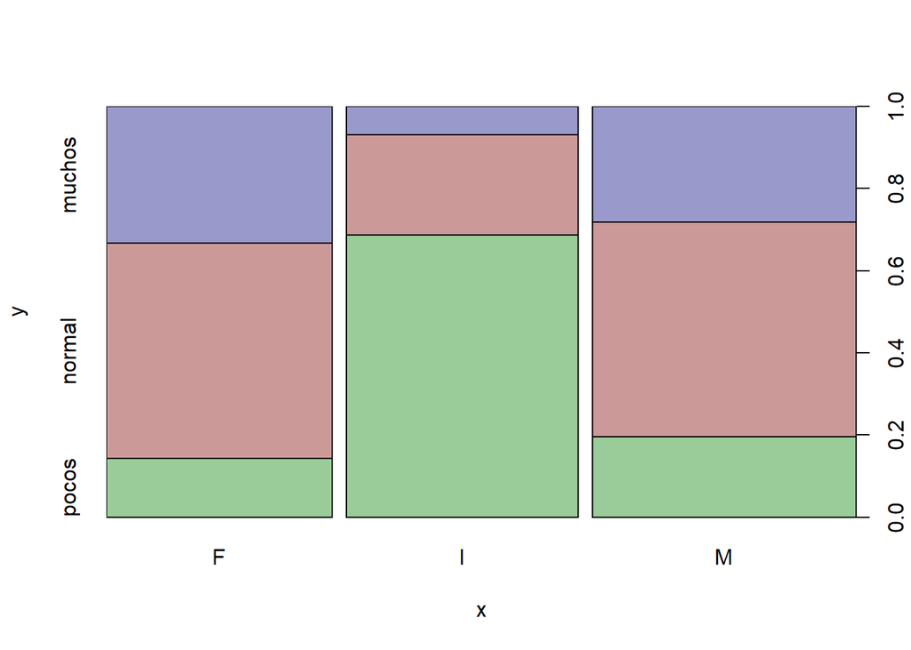

```r
plot(x = datos$Genero, y = datos$anillos_disc,
     col = c("#99cc99", "#cc9999", "#9999cc", "#9c9c9c"))
```

### Visualizando NUMERICA VS CATEGORICA

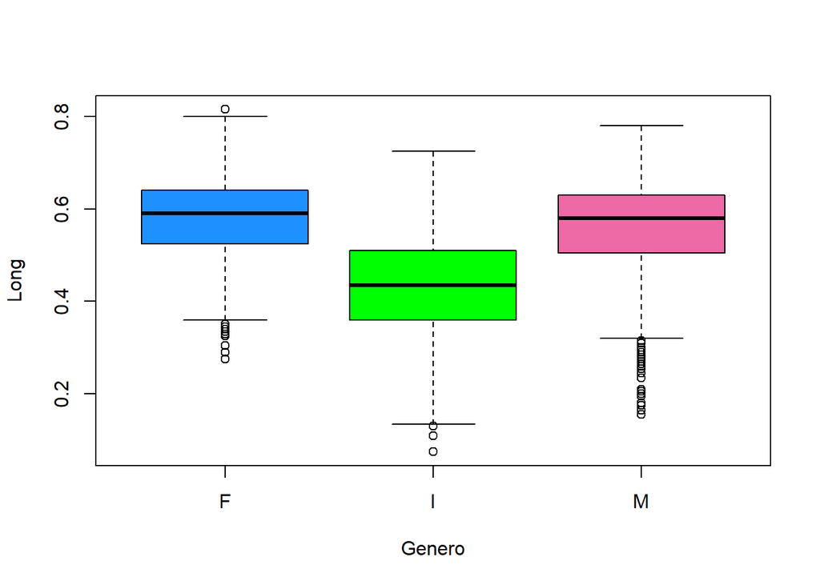

```r
boxplot(Long ~ Genero, col=c("dodgerblue","green", "hotpink2"))
```

### Visualizando NUMERICA VS NUMERICA: DISPERSION

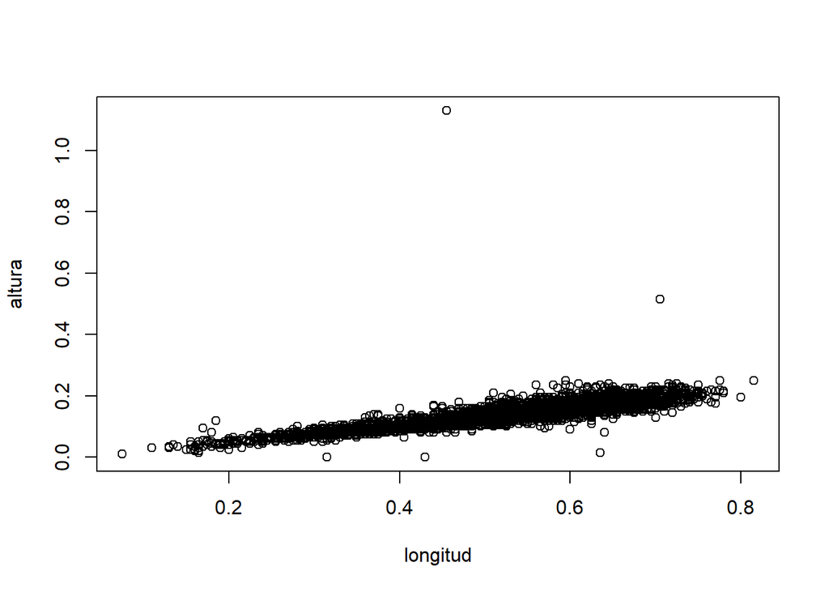

```r
plot(x=Long, y=Altura,
     xlab='longitud',
     ylab='altura')
```

También podemos hacer intervenir otra variable!

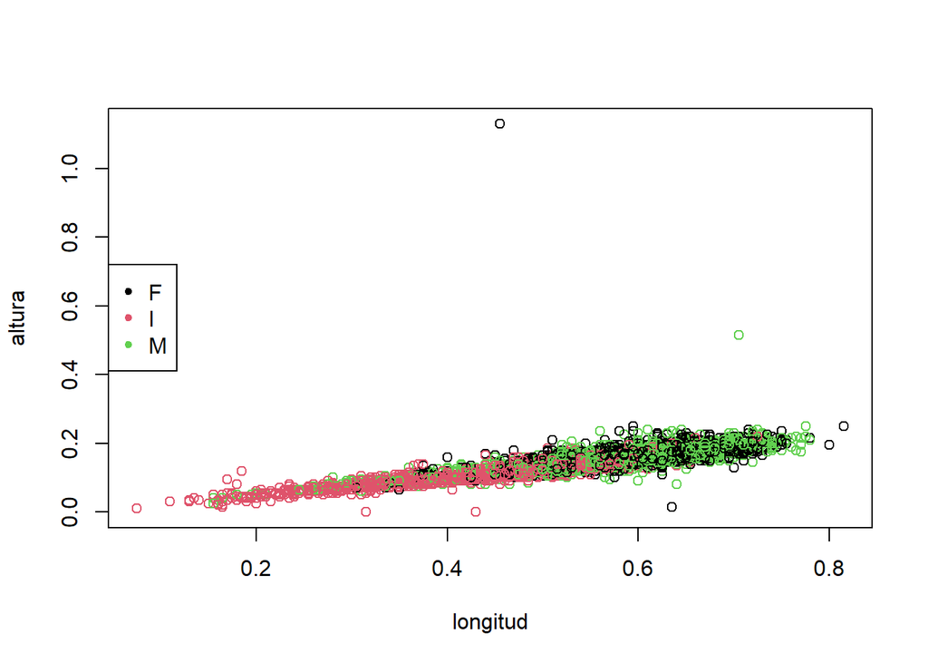

```r
plot(x=Long, y=Altura,
     xlab='longitud',
     ylab='altura', col=as.factor(Genero))
legend('left', legend=c('F', 'I','M'),
       pch=20, col=1:3)
```

## MEDIDAS RESUMEN PARA VARIABLES NUMERICAS

```r
#para mirar sobre todas las variables:
summary(datos)
```

```
##  Genero        Long            Diam            Altura            Peso
##  F:1307   Min.   :0.075   Min.   :0.0550   Min.   :0.0000   Min.   :0.0020
##  I:1342   1st Qu.:0.450   1st Qu.:0.3500   1st Qu.:0.1150   1st Qu.:0.4415
##  M:1528   Median :0.545   Median :0.4250   Median :0.1400   Median :0.7995
##           Mean   :0.524   Mean   :0.4079   Mean   :0.1395   Mean   :0.8287
##           3rd Qu.:0.615   3rd Qu.:0.4800   3rd Qu.:0.1650   3rd Qu.:1.1530
##           Max.   :0.815   Max.   :0.6500   Max.   :1.1300   Max.   :2.8255
##      Peso1            Peso2            Peso3          N.anillos
##  Min.   :0.0010   Min.   :0.0005   Min.   :0.0015   Min.   : 1.000
##  1st Qu.:0.1860   1st Qu.:0.0935   1st Qu.:0.1300   1st Qu.: 8.000
##  Median :0.3360   Median :0.1710   Median :0.2340   Median : 9.000
##  Mean   :0.3594   Mean   :0.1806   Mean   :0.2388   Mean   : 9.934
##  3rd Qu.:0.5020   3rd Qu.:0.2530   3rd Qu.:0.3290   3rd Qu.:11.000
##  Max.   :1.4880   Max.   :0.7600   Max.   :1.0050   Max.   :29.000
##  anillos_disc
##  muchos: 960
##  normal:1810
##  pocos :1407
##
##
##
```

```r
#para pedirlo sobre una variable en particular:
 mean(Long) #media_Longitud
```

```
## [1] 0.5239921
```

```r
 var(Long) #varianza_Longitud. esto no aparece en summary
```

```
## [1] 0.01442231
```

```r
 sd(Long) #desvio_Longitud . esto no aparece en summary
```

```
## [1] 0.1200929
```

```r
quantile(Long, probs=0.25) # cuantil 0.25= Q1 = primer cuartil
```

```
##  25%
## 0.45
```

```r
quantile(Long, probs=0.40) #cuantil 0.4
```

```
##  40%
## 0.51
```

```r
Q90= quantile(Long, probs=0.90) #calcula el cuantil 0,9, llevado a % es P90
Q90*100 # el percentil 90
```

```
## 90%
##  66
```

También pueden calcularse para subgrupos:

```r
sapply(split(x=Long, f=Genero), mean)
```

```
##         F         I         M
## 0.5790933 0.4277459 0.5613907
```

Algo más prolijo, armamos una tabla de medidas resumen para estas variables:

```r
library(knitr)
library(psych)
kable(describe(datos_num),skew = F,
      caption = "Estadísticas descriptivas de las variables cuantitativas")
```

Estadísticas descriptivas de las variables cuantitativas

|  | vars | n | mean | sd | median | trimmed | mad | min | max | range | skew | kurtosis | se |
| --- | --- | --- | --- | --- | --- | --- | --- | --- | --- | --- | --- | --- | --- |
| Long | 1 | 4177 | 0.5239921 | 0.1200929 | 0.5450 | 0.5324783 | 0.1186080 | 0.0750 | 0.8150 | 0.7400 | -0.6394138 | 0.0616411 | 0.0018582 |
| Diam | 2 | 4177 | 0.4078813 | 0.0992399 | 0.4250 | 0.4146994 | 0.0963690 | 0.0550 | 0.6500 | 0.5950 | -0.6087607 | -0.0482711 | 0.0015355 |
| Altura | 3 | 4177 | 0.1395164 | 0.0418271 | 0.1400 | 0.1402498 | 0.0370650 | 0.0000 | 1.1300 | 1.1300 | 3.1265706 | 75.8953091 | 0.0006472 |
| Peso | 4 | 4177 | 0.8287422 | 0.4903890 | 0.7995 | 0.7995646 | 0.5285469 | 0.0020 | 2.8255 | 2.8235 | 0.5305773 | -0.0264756 | 0.0075877 |
| Peso1 | 5 | 4177 | 0.3593675 | 0.2219629 | 0.3360 | 0.3439231 | 0.2349921 | 0.0010 | 1.4880 | 1.4870 | 0.7185815 | 0.5912553 | 0.0034344 |
| Peso2 | 6 | 4177 | 0.1805936 | 0.1096143 | 0.1710 | 0.1733193 | 0.1178667 | 0.0005 | 0.7600 | 0.7595 | 0.5914271 | 0.0809994 | 0.0016960 |
| Peso3 | 7 | 4177 | 0.2388309 | 0.1392027 | 0.2340 | 0.2305173 | 0.1475187 | 0.0015 | 1.0050 | 1.0035 | 0.6204809 | 0.5281636 | 0.0021538 |
| N.anillos | 8 | 4177 | 9.9336845 | 3.2241690 | 9.0000 | 9.6410410 | 2.9652000 | 1.0000 | 29.0000 | 28.0000 | 1.1133019 | 2.3239123 | 0.0498868 |

### Correlaciones bivariadas

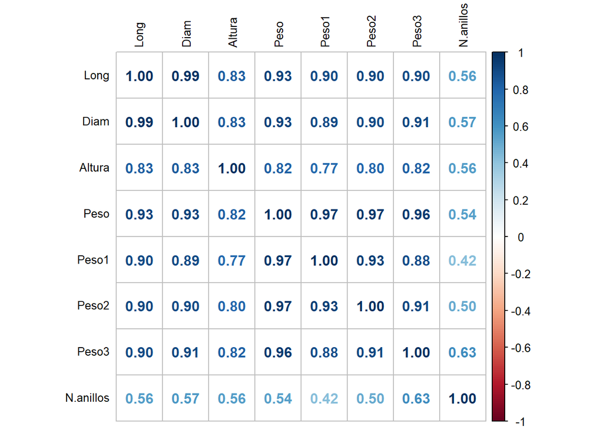

```r
library(corrplot)
correl <- cor(datos_num)
corrplot(correl, method="number", tl.col="black", tl.cex=0.8)
```

También podemos ver gráficos de a pares para todas las variables numéricas.

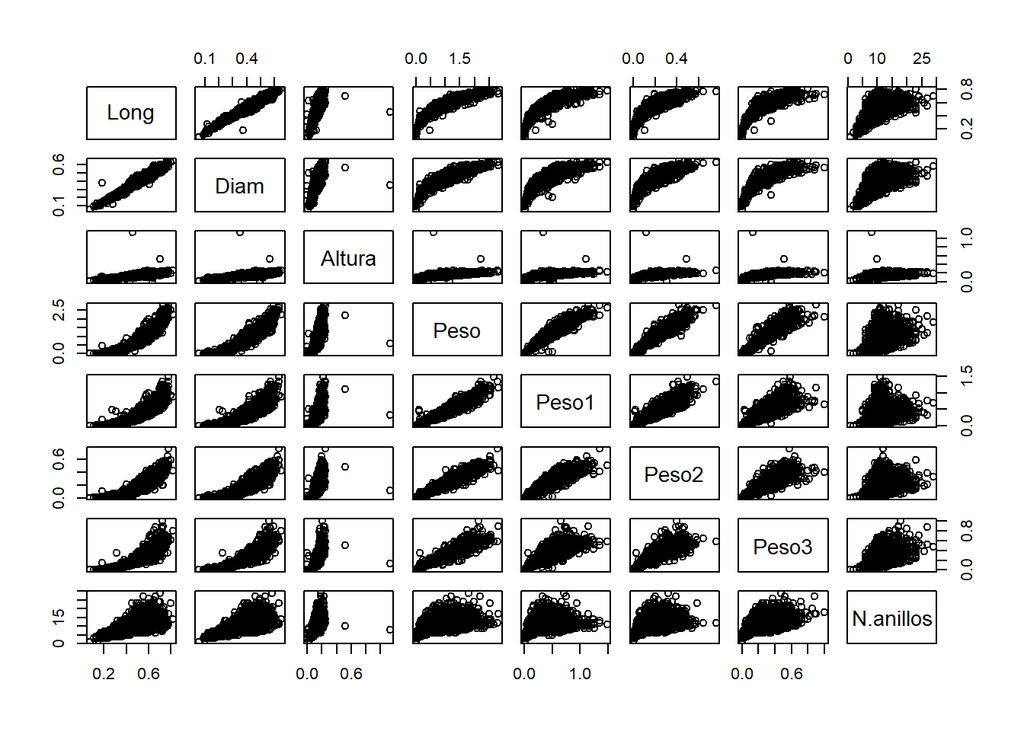

```r
pairs(datos_num)
```